# A meta-analysis of biocontrol potential and herbivore pressure in olive crops: Does integrated pest management make a difference? - ScienceDirect

## Figures (2)

[figure not shown]

[figure not shown]

## Tables (1)

1. Table 1

## Extras (7)

[figure not shown]

## [Basic and Applied Ecology](https://www.sciencedirect.com/journal/basic-and-applied-ecology)

[Volume 63](https://www.sciencedirect.com/journal/basic-and-applied-ecology/vol/63/suppl/C), September 2022, Pages 115-124

# REVIEW ARTICLE A meta-analysis of biocontrol potential and herbivore pressure in olive crops: Does integrated pest management make a difference?

[SashaVasconcelos<sup>a</sup><sup>b</sup><sup>c</sup><sup>d</sup>](https://www.sciencedirect.com/science/article/pii/S1439179122000482#!)[MattiasJonsson<sup>d</sup>](https://www.sciencedirect.com/science/article/pii/S1439179122000482#!)[RubenHeleno<sup>e</sup>](https://www.sciencedirect.com/science/article/pii/S1439179122000482#!)[FranciscoMoreira<sup>a</sup><sup>b</sup><sup>c</sup>](https://www.sciencedirect.com/science/article/pii/S1439179122000482#!)[PedroBeja<sup>a</sup><sup>b</sup><sup>c</sup>](https://www.sciencedirect.com/science/article/pii/S1439179122000482#!)

https://doi.org/10.1016/j.baae.2022.05.009[Get rights and content](https://s100.copyright.com/AppDispatchServlet?publisherName=ELS&contentID=S1439179122000482&orderBeanReset=true)

Under a Creative Commons [license](https://creativecommons.org/licenses/by-nc-nd/4.0/)

Open access

## Abstract

Agricultural policies in the European Union (EU) are increasingly promoting organic management and [integrated pest management](https://www.sciencedirect.com/topics/earth-and-planetary-sciences/integrated-pest-management) (IPM) as environmentally friendly alternatives to high-input conventional management. While there is consensus that organic management is largely beneficial for biodiversity, including the natural enemies of [crop pests](https://www.sciencedirect.com/topics/earth-and-planetary-sciences/crop-pest), IPM has been much less scrutinized. We conducted a meta-analysis based on 294 observations extracted from 18 studies to compare the effects of conventional, IPM and organic management on biocontrol potential and herbivore pressure in olive, an important cash crop in the EU. Information about the management practices used was also compiled to assess differences in intensity between the three management strategies. Results suggest that IPM is predominantly based on intensive practices, employing chemical control rather than preventive measures as a first resort. Biocontrol potential and herbivore pressure were similar in conventional management and IPM. Moreover, biocontrol potential was higher in organic crops than in crops under IPM, especially when considering canopy-dwelling natural enemies. Although organic management enhanced biocontrol potential, it also benefitted some olive pests, and in both cases effects were more pronounced at warmer temperatures. Our results suggest that, in its current form, IPM might not significantly affect biocontrol potential or herbivore pressure when compared with conventional olive [crop management](https://www.sciencedirect.com/topics/agricultural-and-biological-sciences/crop-management). A shift to a more comprehensive implementation of IPM practices is thus needed, involving the use of proactive measures to promote natural enemies and regulate olive pests before resorting to chemical control. Moreover, greater use of non-chemical inputs might be required for effective regulation of olive pests in organic olive crops.

## Keywords

Integrated pest management

Organic management

Olive farming

Biocontrol

Meta-analysis

## Introduction

Global [food production](https://www.sciencedirect.com/topics/earth-and-planetary-sciences/food-production) has doubled over the last 60 years to meet rising demands of the growing human population and the increasing per capita consumption (Wittwer et al., 2021). However, this has come at a high environmental cost, including in particular the strong negative impacts of synthetic pesticides and mineral [fertilizers](https://www.sciencedirect.com/topics/earth-and-planetary-sciences/fertiliser) on non-target organisms, human health and food quality (Pimentel et al., 2005; Tilman et al., 2002). To counteract these impacts in the European Union (EU), where agriculture currently occupies 48% of the land (Rega et al., 2020), policies are increasingly promoting organic management and principles of [integrated pest management](https://www.sciencedirect.com/topics/earth-and-planetary-sciences/integrated-pest-management) (IPM) as more environmentally-friendly options. For instance, the EU directive on sustainable use of pesticides (Directive 2009/128/EC) required all countries to have plans to adopt principles of IPM by 2014. More recently, the EU Farm to Fork strategy aims at halving the risk and use of synthetic pesticides by 2030, largely by promoting the adoption of organic management and IPM (European Commission, 2020). However, while there is substantial evidence to support organic management as a less harmful alternative to conventional farming, with several quantitative syntheses providing consensus about its benefits for biodiversity (e.g., Bengtsson et al., 2005; Lichtenberg et al., 2017), the effects of IPM have been subject to far less scrutiny (but see Katayama et al., 2019).

IPM is a decision support system for crop protection in integrated farming, where the main goal is to reconcile ecological preservation with economic profitability through the balanced use of chemical, biological and cultural practices (Boller et al., 2004; Mili et al., 2017). There are, however, multiple definitions of IPM (Deguine et al., 2021), which ultimately boil down to two main approaches. One is the comprehensive form of IPM which prioritizes the enhancement of biodiversity and associated services, in particular biocontrol (i.e., conservation biocontrol, whereby resident natural enemies in an ecosystem are boosted by targeted human interventions; Stenberg et al., 2021), before any form of chemical control is used (Zalucki et al., 2009; Hokkanen et al., 2015; Lundin et al., 2021). It is typically represented as a pyramid, where priority is given to proactive actions (e.g., crop rotation, reduced or [no tillage](https://www.sciencedirect.com/topics/earth-and-planetary-sciences/zero-tillage), fostering of natural enemies) at the base of the pyramid, while reactive actions (chemical pesticides) at the top of the pyramid should only be used when other measures fail to maintain pest densities below intervention thresholds (Hokkanen et al., 2015; Lundin et al., 2021). The other approach, which is prevailing, is more limited as it simply resorts to chemical control when predefined intervention thresholds are exceeded (Deguine et al., 2021; Hokkanen et al., 2015). This latter approach likely prevails as farmers tend to opt for the less labor-intensive option of chemical control, which is potentially more effective in the short term and perceived to ensure fewer crop losses (Deguine et al., 2021). These decisions can partly stem from a poor farmer involvement in IPM development, as they are often unaware of practices compatible with IPM (Deguine et al., 2021), or of the ecological concepts underpinning its principles (Wyckhuys et al., 2019). Organic management differs from IPM by prohibiting or strictly limiting the use of synthetic inputs, fostering instead natural enemies and limiting the use of pesticides to those produced from natural sources (e.g., organic [insecticides](https://www.sciencedirect.com/topics/earth-and-planetary-sciences/insecticide) and bacterial biological control agents). Productivity tends to be lower though, as this management strategy usually generates lower yields as synthetic fertilizers are not used (Seufert et al., 2012; Wittwer et al., 2021), but profitability can be comparable or even higher due to higher product pricing (Wittwer et al., 2021).

While various individual scientific studies have compared conventional, organic and IPM in terms of their biodiversity impacts (e.g., Campos-Herrera et al., 2008; Krauss et al., 2011; Meng et al., 2016; Pekár, 1999), meta-analyses have focused mainly on comparisons between conventional and organic management. These quantitative syntheses point to largely positive effects of organic management for biodiversity, particularly on service-providing organisms such as natural enemies of [crop pests](https://www.sciencedirect.com/topics/earth-and-planetary-sciences/crop-pest) (Bengtsson et al., 2005; Garratt et al., 2011; Katayama et al., 2019; Lichtenberg et al., 2017; Tuck et al., 2014). Natural enemies are organisms that can exert top-down control on herbivores, which in turn can be considered pests or non-pests depending on the damage they produce to crops. Herbivorous insects (including pests) on the other hand have shown both positive or no responses to organic management (e.g., Bengtsson et al., 2005; Lichtenberg et al., 2017). Muneret et al. (2018) explicitly examined the effects of organic management on biocontrol potential and [pest infestation](https://www.sciencedirect.com/topics/earth-and-planetary-sciences/pest-infestation) relative to conventional management, revealing a higher level of biocontrol potential, but also of pest infestation, though only when the pests in question were weeds. To date, the effects of IPM on biodiversity have only been addressed in one meta-analysis (Katayama et al., 2019). Considering vertebrate, invertebrate and microbial taxa in [perennial crops](https://www.sciencedirect.com/topics/agricultural-and-biological-sciences/perennial-crop) around the world, these authors found that overall species richness, but not abundance, was higher in systems under integrated farming than in those managed conventionally. The similar abundance was attributed to higher natural enemy and lower herbivore abundance in integrated farming. Moreover, no differences in overall species richness or abundance in relation to organic management were found, although specific effects on natural enemies and herbivores were not assessed. However, the magnitude and direction of effect sizes varied greatly with the crop studied. This suggests that while the inclusion of multiple crops in meta-analyses is important to detect general trends, it is equally important to evaluate the effects of IPM on specific crops, as these might be obscured in global analyses.

We performed a meta-analysis comparing conventional, IPM and organic management in terms of their effects on biocontrol potential and on herbivore pressure in olive crops. Olive was selected because it is a widely cultivated perennial crop in EU Mediterranean countries, which alone account for 54% of global olive production (FAOSTAT, 2020). We focused on arthropods as they play a key role in the provision of biocontrol services, but also as crop pests. In the particular case of olive orchards, the most damaging and widespread pests across the Mediterranean region are the [olive fruit fly](https://www.sciencedirect.com/topics/agricultural-and-biological-sciences/olive-fruit-fly) (*Bactrocera oleae*) and olive moth (*[Prays oleae](https://www.sciencedirect.com/topics/agricultural-and-biological-sciences/prays-oleae)*) (Daane & Johnson, 2010; Gonzalez et al., 2015). Given that the limited form of IPM currently prevails in many agricultural systems, we also characterized the three management strategies in terms of the management practices used. Specifically, we sought to determine (i) the differences in management intensity between management strategies; and (ii) whether biocontrol potential (measured as natural enemy abundance, diversity, parasitism and predation rates) and herbivore pressure (measured as herbivore abundance and damage) differ between strategies.

## Materials and methods

### Study selection and data extraction

We conducted a literature search by adopting a Population-Intervention-Comparator-Outcome (PICO) framework (Koricheva et al., 2013) to select keywords, defining olive orchards as the Population, IPM/organic management as the Intervention (treatment groups), conventional/IPM as the [Comparator](https://www.sciencedirect.com/topics/earth-and-planetary-sciences/comparators) (control groups) and biocontrol potential/herbivore pressure as the Outcome. The search was carried out on Web of Science (last update in February 2022) and yielded 499 records using the search string: (“olea europaea” OR “olive farm*” OR “olive orchard*” OR “olive grove*” OR “olive plantation*”) AND (organic* OR non-organic* OR integrated* OR extensive* OR conventional* OR traditional*) AND (biodiversity OR pest* OR herbiv* OR phytophag* OR damage* OR infest* OR “biological control” OR “pest control” OR natural enem* OR beneficial* OR controller* OR parasit* OR predat*). In addition, we found nine records in the reference lists of the studies (papers) obtained through the search, yielding a total of 508 records.

The studies were screened by sequentially reading the title and abstract, with 47 studies read in full to determine whether they met the following criteria: (i) the study provided a pairwise comparison of the management strategies, for at least two of the three management strategies (conventional, [IPM](https://www.sciencedirect.com/topics/earth-and-planetary-sciences/integrated-pest-management), organic); (ii) comparisons between strategies involved a measure of biocontrol potential (natural enemy abundance, diversity, parasitism and/or predation) and/or herbivore pressure (herbivore abundance and/or damage); only pairwise comparisons were used to ensure more similar climatic and soil conditions in the compared orchards; (iii) the study reported the mean, a measure of variance (i.e., standard deviation, standard error, or 95% confidence interval) and sample size for the response variables. When only standard errors or 95% confidence intervals were reported, they were converted to standard deviations. We contacted the authors of six studies that included the necessary data except for the mean and/or a measure of variance by email and received information for two of the studies. Overall, 18 studies met the criteria for inclusion in the meta-analysis (see Appendix A: Table 1 and Fig. 1).

For each study, the means, measures of variance and sample sizes were extracted directly from the text or tables (*n* = 7), from graphs (*n* = 9) using WebPlotDigitizer 4.2 (Rohatgi, 2015), or were provided by the authors (*n* = 2). We separately compiled the natural enemy and herbivore data, assembling three datasets for each trophic group, involving comparisons between: (i) conventional and IPM management (conventional set as the control); (ii) conventional and organic management (conventional set as the control); and (iii) IPM and organic management (IPM set as the control). Whenever studies provided comparisons for more than one natural enemy and/or herbivore taxon, we calculated an effect size for each comparison. Likewise, when multiple temporal data points were provided, we calculated as many effect sizes as possible. We also compiled information about the farming practices used in each strategy to assess management intensity, and to check whether IPM consisted of either the limited or the more comprehensive approach: the use of synthetic [insecticides](https://www.sciencedirect.com/topics/earth-and-planetary-sciences/insecticide), herbicides, synthetic fertilizers, organic insecticides, bacterial [biocontrol agents](https://www.sciencedirect.com/topics/earth-and-planetary-sciences/biocontrol-agent), kaolin clay, copper, mass trapping, tillage, mowing and organic fertilizers (see Appendix A: Table 2).

### Data analysis

Management intensity was explored with a heatmap illustrating the percentage of studies that reported the use (0/1) of the aforementioned farming practices in each of the three management strategies. In the meta-analysis, effect sizes for comparisons between the management strategies were calculated using the standardized mean difference (Hedges’ d) (Hedges & Olkin, 1985). We chose this index as it is frequently employed in ecological meta-analyses, it accounts for differences in sampling effort among studies and corrects for small sample sizes. It also allows for zero values in either the control or treatment groups (Rosenberg & Rothstein, 2013).

We used multi-level models with [restricted maximum likelihood](https://www.sciencedirect.com/topics/agricultural-and-biological-sciences/restricted-maximum-likelihood) (REML) estimation (Cheung et al., 2014; Koricheva et al., 2013), as they allow for non-independence in the data. To account for dependence between observations (each comparison between two management strategies) obtained from the same study, we nested observations within studies (syntax: 1 | study/observation) (Nakagawa et al., 2017). Because most of the studies that shared some authors were conducted in the same locations and sometimes based on the same sampling designs, we also ran the models with author included as a random factor (syntax: 1 | author/study/observation). Studies were considered dependent when they shared a first and/or last author. The nested random structure that best fit the datasets was selected from the models with the lowest [Akaike Information Criterion](https://www.sciencedirect.com/topics/earth-and-planetary-sciences/akaike-information-criterion) (AIC). In all cases the models where observations were nested within studies had the lowest AIC (see Appendix A: Table 3), and were thus retained in the analyses.

To assess heterogeneity among effect sizes within the three biocontrol potential and three herbivore pressure datasets, we used the Q statistic (Cheung et al., 2014). We then calculated the proportion of variance attributed to each level in our models, namely: within-observation heterogeneity/sampling error (level 1); within-study heterogeneity (level 2); and between-study heterogeneity (level 3) (Nagakawa & Santos, 2012). Significant heterogeneity was observed among effect sizes, in most cases due to variation within studies, followed by variation between studies and within observations (i.e., sampling error) (Table 1). In an attempt to explain part of this heterogeneity, we extracted information about the following moderator variables from each study: the sampling location (olive tree canopy/ground), the sampled arthropod order, years since conversion to IPM or organic management, the type of herbivore (olive-pest herbivore/other herbivores), the measure of biocontrol potential (abundance/diversity/predation/parasitism) and of herbivore pressure (abundance/damage). We also considered temperature, because it might vary markedly across studies carried out in different countries, years and months, and is known to strongly influence arthropod development (Logan et al., 2006). For each study location, we thus obtained mean minimum and maximum monthly temperatures available in WorldClim at a resolution of 2.5 min (∼ 21 km<sup>2</sup>). These data derive from the Climate Research Unit (CRU-TS-4.03; Harris et al., 2014) and are downscaled with WorldClim 2.1 for bias correction (Fick & Hijmans, 2017). The average of the mean minimum and maximum monthly temperatures was then used to approximate the mean monthly temperatures. The temperature data was matched with the study sampling periods as closely as possible, by extracting temperatures for the specific years and months in which study sampling was conducted. The temperature for each data point was then approximated as the average temperature of the months when data was collected. Of the moderators obtained, the measures of biocontrol potential and of herbivore pressure, as well as sampled arthropod order, were excluded from the analyses because of the very unbalanced distribution of effect sizes between their categories in most datasets. Because information about the number of years since conversion to IPM/organic management was not provided in most studies, this moderator was also excluded from the analysis. Sampling location was used in the biocontrol potential models, herbivore type in the herbivore pressure models, and temperature in both. We were unable to use sampling location in the herbivore pressure models due to limited ground sampling data for two of the three herbivore datasets.

Table 1. Cochran's Q statistic quantifying heterogeneity among effect sizes in the three natural enemy and three herbivore datasets. The distribution of variance in the models, attributable to within-observation heterogeneity (sampling error), and within- and between-study heterogeneity, is also provided.

| Datasets Empty Cell | Q (*P*-value) Empty Cell | I<sup>2</sup> Level 1 (within-observation) | I<sup>2</sup> Level 2 (within-study) | I<sup>2</sup> Level 3 (between-study) |
| --- | --- | --- | --- | --- |
| *Biocontrol potential* |  |  |  |  |
| Conventional vs IPM | 208.6 (<0.001) | 19.8% | 61.9% | 18.2% |
| Conventional vs Organic | 572.3 (<0.001) | 6.9% | 76.4% | 16.8% |
| IPM vs Organic | 842.3 (<0.001) | 5.1% | 82.3% | 12.6% |
| *Herbivore pressure* |  |  |  |  |
| Conventional vs IPM | 71.5 (<0.001) | 28.7% | 27.8% | 43.5% |
| Conventional vs Organic | 381.9 (<0.001) | 3.3% | 70.8% | 25.9% |
| IPM vs Organic | 158.1 (<0.001) | 8.7% | 28.9% | 62.4% |

Potential publication bias in the datasets was assessed through the inspection of contour-enhanced funnel plots (Peters et al., 2008) and by testing for funnel plot asymmetry using Egger's regression test (Egger et al., 1997). This test was extended to multi-level models by including the standard error of the effect sizes as a moderator. An intercept deviating significantly from zero indicates asymmetry in the funnel plot (Nagakawa & Santos, 2012), and asymmetry was considered at *P* = 0.10 (Egger et al., 1997). We also calculated fail-safe numbers to estimate how many unpublished, non-significant or missing studies would be needed to make significant results non-significant. If a fail-safe number exceeds the threshold of 5n + 10, where *n* = the number of observations, significant overall effects can be considered robust regardless of potential publication bias (Rosenberg, 2005).

We compared the models with and without outliers and influential observations, as they can affect the validity of meta-analytic findings (Viechtbauer & Cheung, 2010). The presence of outliers was assessed using quantile-quantile plots and boxplots (Wang & Bushman, 1998), while influential observations were identified using Cook's distance (Cook & Weisberg, 1982; Viechtbauer & Cheung, 2010). Following Muneret et al. (2018), we used a bootstrap approach to test whether our results were influenced by temporal dependence among effect sizes (both between-year and within-year dependence). Results were considered robust when the mean and 95% confidence intervals of the estimates resulting from the bootstrap were included in the confidence intervals of the global mean in each model. Analyses were performed with the ‘metafor’ package (Viechtbauer, 2010) in R (R Development Core Team, 2020).

## Results

### Study characteristics

Overall, we extracted 294 observations from 18 studies conducted in five of the nine olive-producing countries in the EU (see Appendix A: Table 1). The majority of studies was carried out in Spain (11 studies), while three studies were carried out in Italy, two in Portugal, and one study each in Croatia and Greece. Data on biocontrol potential was obtained from 15 studies, while only nine studies provided data on herbivore pressure. Most studies measured natural enemy and/or herbivore abundance, whereas natural enemy diversity, predation, parasitism and damage were the focus of only one study each. The natural enemy taxonomic groups that were sampled in the studies included spiders (Araneae), lacewings (Neuroptera), [lady beetles](https://www.sciencedirect.com/topics/agricultural-and-biological-sciences/coccinellidae) (Coccinellidae), pirate bugs (Anthocoridae), a parasitoid wasp (*Psyttalia concolor*) and an ant (*Tapinoma nigerrimum*). The sampled herbivore taxa included butterflies/moths (Lepidoptera), aphids/scale insects/cicadas/leafhoppers (Homoptera), and four olive croppests: the olive moth (*[Prays oleae](https://www.sciencedirect.com/topics/agricultural-and-biological-sciences/prays-oleae)*), olive [psyllid](https://www.sciencedirect.com/topics/agricultural-and-biological-sciences/jumping-plant-louse) (*Euphyllura olivina*), black scale (*[Saissetia oleae](https://www.sciencedirect.com/topics/agricultural-and-biological-sciences/saissetia-oleae)*) and olive thrip (*Liothrips oleae*) (see Appendix A: Table 1). None of the studies provided comparisons between management strategies for the [olive fruit fly](https://www.sciencedirect.com/topics/agricultural-and-biological-sciences/olive-fruit-fly) (*Bactrocera oleae*).

### Management intensity

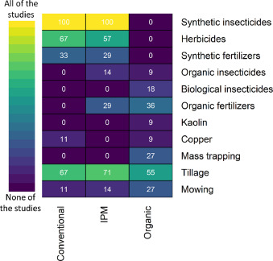

Fig. 1. Heatmap illustrating the percentage of studies (papers) that reported the use (0/1) of 11 main farming practices in each of the three management strategies.

### Biocontrol potential

Biocontrol potential, represented mainly by natural enemy abundance (see Appendix A: Table 1), did not differ between olive crops under conventional management and IPM (Hedges’ *d* = 0.45; 95% CI = −0.19, 1.1). This result did not differ depending on whether canopy- or ground-dwelling natural enemies were considered, and was not influenced by temperature (Fig. 2A). However, biocontrol potential was higher in IPM after the removal of outliers (*n* = 2), but not after removing influential observations (*n* = 3) (see Appendix A: Fig. 3A). No influence of between- or within-year temporal dependence among effect sizes was detected (see Appendix A: Fig. 3A). Biocontrol potential was higher in organic than in conventional olive crops (Hedges’ *d* = 1.12; 95% CI = 0.39, 1.86), both for canopy and ground-dwelling natural enemies, and particularly at warmer temperatures (Fig. 2A). This positive effect of organic management remained similar after excluding outliers (*n* = 10) as well as influential observations (*n* = 3), and was robust to temporal dependence among effect sizes (see Appendix A: Fig. 3A). Biocontrol potential was higher in organic crops than in those under IPM (Hedges’ *d* = 0.69; 95% CI = 0.11, 1.28) (Fig. 2A), though only for canopy-dwelling natural enemies (Fig. 2A). The positive effect also increased significantly with temperature (Fig. 2A). This result also remained similar after the sensitivity analyses (see Appendix A: Fig. 3A).

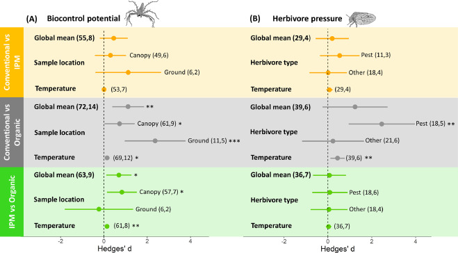

Fig. 2. Forest plots displaying effects of the three management strategies for (A) biocontrol potential and (B) herbivore pressure. A positive Hedges’ d value indicates a higher level of biocontrol potential or herbivore pressure in a treatment group (IPM or organic management) relative to the control group (conventional or IPM). The mean effect size ± 95% CI is presented for the global mean (intercept-only model) and for the moderator variables: sampling location (canopy/ground), herbivore type (olive-pest herbivores/other herbivores) and temperature. The number of effect sizes and studies are provided in brackets. Significant differences are indicated (****P* < 0.001; ***P* < 0.01; **P* < 0.05).

### Herbivore pressure

Herbivore pressure, almost exclusively represented by herbivore abundance (see Appendix A: Table 1), did not differ between conventionally managed olive crops and those under IPM (Hedges’ *d* = 0.2; 95% CI = −0.55, 0.95) (Fig. 2B). This result did not vary with the type of herbivore (olive-pest/other), or with temperature (Fig. 2B). The overall level of herbivore pressure was also similar between conventional and organically managed olive crops (Hedges’ *d* = 1.24; 95% CI = −0.24, 2.72) (Fig. 2B). However, the abundance of olive-pest herbivores was higher in organic crops, whereas no significant differences were found for other herbivores (Fig. 2B). There was also a significant effect of temperature, with higher herbivore pressure in organic than in conventional crops at warmer temperatures (Fig. 2B). Herbivore pressure did not differ between crops under IPM and organic management (Hedges’ *d* = 0.07; 95% CI = −0.68, 0.83) (Fig. 2B), regardless of herbivores being olive-pests or not (Fig. 2B). The result did not vary with temperature (Fig. 2B). Sensitivity analyses revealed that overall herbivore pressure remained similar among management strategies after excluding outliers, influential observations, and were robust to the temporal dependence among effect sizes (see Appendix A: Fig. 3B).

### Publication bias

There was evidence of publication bias, as asymmetry was detected in all funnel plots, except for the comparison of biocontrol potential between conventional and organic management (see Appendix A: Fig. 2). This was supported by Egger's regression test for funnel plot asymmetry, although asymmetry was only marginal in the comparison of herbivore pressure between IPM and organic management (see Appendix A: Table 4). However, in all instances where significant differences were found between management strategies, the fail-safe numbers were far higher than the established threshold. This was the case for the higher level of biocontrol potential in organic compared with conventionally managed olive crops (1525 in relation to threshold of 370 (5n + 10 = 370, with *n* = 72 observations), and in organically managed crops relative to those under IPM (7202 in relation to threshold of 325 (5n + 10 = 325, with *n* = 63 observations)).

## Discussion

Our meta-analysis highlights the need for more scrutiny of [IPM](https://www.sciencedirect.com/topics/earth-and-planetary-sciences/integrated-pest-management) practices, as it suggests that the limited form of IPM is currently prevailing in olive crops, and fails to boost levels of biocontrol potential relative to conventional management. Moreover, organic management increases biocontrol potential relative to IPM, though only when considering canopy-dwelling natural enemies, and particularly at warmer temperatures. No differences in herbivore pressure were found between conventionally managed crops and those under IPM. Lastly, we show that while organic management enhances biocontrol potential relative to IPM and conventional management, it also enhances some olive-pest herbivores, and more so at warmer temperatures.

### Potential limitations and shortcomings

When interpreting the results of the meta-analysis, some limitations need to be considered, though they are unlikely to affect our main results and conclusions. The most important is the small number of studies that met the criteria for inclusion, particularly those providing herbivore responses, and which can limit the inferences drawn. We tried to circumvent this problem by maximizing the number of effect sizes gathered from each study, through the extraction of multiple temporal data points. Sensitivity analyses showed that the resulting temporal dependence among effect sizes did not significantly influence overall results. Apart from natural enemy and herbivore abundance, additional proxies of biocontrol potential (e.g., parasitism and predation rates) and of herbivore pressure (crop damage) were rare in the studies. Furthermore, only three studies provided information about yield, with no associated measures of variance, which prohibited its inclusion in the analyses. This information would be crucial to understand whether increases in biocontrol potential and reductions in herbivore pressure in olive crops actually translate to yield gains. We also found evidence of publication bias in most of the funnel plots and Egger's regression tests. However, in all the asymmetric funnel plots, the observations lay in areas of both significance and non-significance, very likely reflecting other sources of heterogeneity in the data rather than a real bias towards publishing significant results (Egger et al., 1997). Lastly, in all cases where a significant global effect of one management strategy was detected relative to another, the fail-safe numbers were far higher than the established thresholds. This further supports the validity of the significant effects detected.

## Conclusions

In its current limited form, [IPM](https://www.sciencedirect.com/topics/earth-and-planetary-sciences/integrated-pest-management) in olive crops appears to represent a negligible improvement in relation to conventional management, both in terms of biocontrol potential and herbivore suppression. Furthermore, a higher level of biocontrol potential was found in organic olive crops than in those under IPM. This suggests that a shift to a more comprehensive implementation of IPM in olive crops is needed, prioritizing proactive actions at the base of the IPM pyramid to promote natural enemies of [crop pests](https://www.sciencedirect.com/topics/earth-and-planetary-sciences/crop-pest) and relying on chemical use only as a last resource (Zalucki et al., 2009). This might involve, for instance, retaining herbaceous cover within olive orchards to boost natural enemy abundance and predation rates (e.g., Álvarez et al., 2021; Paredes et al., 2013), as well as maintaining complex landscapes with more natural/semi-natural habitat and less crop cover that can benefit natural enemies and contribute to reductions in olive pest abundance (e.g., Costa et al., 2020). However, the paucity of studies providing information about parasitism/predation, crop damage and/or yield, prohibits assessments of the contributions natural enemies make to olive pest suppression and to production levels across management strategies. The ongoing intensification of olive farming also presents a challenge to this needed shift in IPM, as agricultural intensification tends to increase the reliance on chemical control (Deguine et al., 2021; Flor et al., 2018). It thus remains to be determined if a more comprehensive form of IPM is feasible in light of the recent and expanding intensification of olive farming, which involves much higher tree densities and more intensive chemical control (Morgado et al., 2020). The positive response of olive-pest herbivores to organic management suggests that higher biocontrol potential in organic olive crops does not translate to reduced pest pressure, and therefore additional organic and/or biological inputs might be required to more effectively regulate pests in organic farming. Overall, our results highlight the need for further research on the impacts of alternative management strategies within crop systems, particularly those of IPM, as this could improve the effectiveness of implemented policy frameworks. Moreover, our results suggest that the EU Farm to Fork strategy may fall short of its key environmental objectives, unless more comprehensive models of IPM are widely implemented.

## CRediT authorship contribution statement

**Sasha Vasconcelos:** Conceptualization, Data curation, Formal analysis, Writing – original draft, Writing – review & editing. **Mattias Jonsson:** Conceptualization, Writing – review & editing. **Ruben Heleno:** Writing – review & editing. **Francisco Moreira:** Conceptualization, Writing – review & editing. **Pedro Beja:** Conceptualization, Writing – review & editing.

## Declaration of Competing Interest

None

## Acknowledgements

We thank José M. Herrera for contributing to an initial discussion about the study; Lucille Muneret for suggestions about data extraction and for kindly providing the R code for the temporal dependence sensitivity analysis; Sérgio Timóteo for helpful discussions at an initial stage of data analysis; and Juan Pablo Cancela for the immense help extracting the temperature data and for making the arthropod illustrations. This research was funded by the Portuguese Foundation for Science and Technology (FCT) through a grant to SV (SFRH/BD/121388/2016) and contracts to RH (UID/BIA/04004/2020) and FM (IF/01053/2015). PB was supported by EDP Biodiversity Chair and MJ by SLU centre for Biological Control. The work was co-funded by the project NORTE-01-0246-FEDER-000063, supported by Norte Portugal Regional Operational Programme (NORTE2020), under the PORTUGAL 2020 Partnership Agreement, through the European Regional Development Fund (ERDF)

## Appendix. Supplementary materials

[Help](https://service.elsevier.com/app/answers/detail/a_id/19286/supporthub/sciencedirect/)

## References

**Aguilera et al., 2021**

G. Aguilera, L. Riggi, K. Miller, T. Roslin, R. Bommarco

**Organic fertilisation enhances generalist predators and suppresses aphid growth in the absence of specialist predators**

Journal of Applied Ecology, 58 (2021), pp. 1455-1465

[CrossRef](https://doi.org/10.1111/1365-2664.13862)[View Record in Scopus](https://www.scopus.com/inward/record.url?eid=2-s2.0-85107027772&partnerID=10&rel=R3.0.0)Google Scholar

**Álvarez et al., 2021**

H.A. Álvarez, R. Jiménez-Muñoz, M. Morente, M. Campos, F. Ruano

**Ground cover presence in organic olive orchards affects the interaction of natural enemies against *Prays oleae*, promoting an effective egg predation**

Agriculture, Ecosystems and Environment, 315 (2021), Article 107441

[Article](https://www.sciencedirect.com/science/article/pii/S0167880921001456)[Download PDF](https://www.sciencedirect.com/science/article/pii/S0167880921001456/pdfft?md5=61162670d9d7a52f761b47f223057a7d&pid=1-s2.0-S0167880921001456-main.pdf)[View Record in Scopus](https://www.scopus.com/inward/record.url?eid=2-s2.0-85103940625&partnerID=10&rel=R3.0.0)Google Scholar

**Bengtsson et al., 2005**

J. Bengtsson, J. Ahnström, A.C. Weibull

**The effects of organic agriculture on biodiversity and abundance: A meta-analysis**

Journal of Applied Ecology, 42 (2005), pp. 261-269

[CrossRef](https://doi.org/10.1111/j.1365-2664.2005.01005.x)[View Record in Scopus](https://www.scopus.com/inward/record.url?eid=2-s2.0-18444408429&partnerID=10&rel=R3.0.0)Google Scholar

**Boller et al., 2004**

E.F. Boller, J. Avilla, E. Joerg, C. Malavolta, F.G. Wijnands, P. Esbjerg

**Integrated production. principles and technical guidelines**

(3rd ed.), OILB/WPRS Bulletin, Zürich (2004)

Google Scholar

**Campos-Herrera et al., 2008**

R. Campos-Herrera, J.M. Gómez-Ros, M. Escuer, L. Cuadra, L. Barrios, C. Gutiérrez

**Diversity, occurrence, and life characteristics of natural entomopathogenic nematode populations from La Rioja (Northern Spain) under different agricultural management and their relationships with soil factors**

Soil Biology and Biochemistry, 40 (2008), pp. 1474-1484

[Article](https://www.sciencedirect.com/science/article/pii/S0038071708000138)[Download PDF](https://www.sciencedirect.com/science/article/pii/S0038071708000138/pdfft?md5=94725624e6db21ee09978b71127f658c&pid=1-s2.0-S0038071708000138-main.pdf)[View Record in Scopus](https://www.scopus.com/inward/record.url?eid=2-s2.0-43649099552&partnerID=10&rel=R3.0.0)Google Scholar

**Cárdenas et al., 2006**

M. Cárdenas, F. Ruano, P. García, F. Pascual, M. Campos

**Impact of agricultural management on spider populations in the canopy of olive trees**

Biological Control, 38 (2006), pp. 188-195

[Article](https://www.sciencedirect.com/science/article/pii/S1049964406000430)[Download PDF](https://www.sciencedirect.com/science/article/pii/S1049964406000430/pdfft?md5=0827a9bc02c33dcb11fffd00c2a0692c&pid=1-s2.0-S1049964406000430-main.pdf)[View Record in Scopus](https://www.scopus.com/inward/record.url?eid=2-s2.0-33744515312&partnerID=10&rel=R3.0.0)Google Scholar

**Cheung, 2014**

M.W.L. Cheung

**Modeling dependent effect sizes with three-level meta-analyses: A structural equation modeling approach**

Psychological Methods, 19 (2014), pp. 211-229

[CrossRef](https://doi.org/10.1037/a0032968)[View Record in Scopus](https://www.scopus.com/inward/record.url?eid=2-s2.0-84902513191&partnerID=10&rel=R3.0.0)Google Scholar

**Cook and Weisberg, 1982**

R.D. Cook, S. Weisberg

**Residuals and influence in regression**

Chapman and Hall, New York (1982)

[Google Scholar](https://scholar.google.com/scholar_lookup?title=Residuals%20and%20influence%20in%20regression&publication_year=1982&author=R.D.%20Cook&author=S.%20Weisberg)

**Costa et al., 2020**

A. Costa, B. Silva, G. Jiménez-Navarro, S. Barreiro, N. Melguizo-Ruiz, J. Rodríguez-Pérez, *et al.*

**Structural simplification compromises the potential of common insectivorous bats to provide biocontrol services against the major olive pest *Prays oleae***

Agriculture, Ecosystems and Environment, 287 (2020), Article 106708

[Article](https://www.sciencedirect.com/science/article/pii/S016788091930324X)[Download PDF](https://www.sciencedirect.com/science/article/pii/S016788091930324X/pdfft?md5=c4dcf69c383e63301125196f42b51aec&pid=1-s2.0-S016788091930324X-main.pdf)[View Record in Scopus](https://www.scopus.com/inward/record.url?eid=2-s2.0-85073320830&partnerID=10&rel=R3.0.0)Google Scholar

**Daane and Johnson, 2010**

K.M. Daane, M.W. Johnson

**Olive fruit fly: Managing an ancient pest in modern times**

Annual Review of Entomology, 55 (2010), pp. 151-169

[CrossRef](https://doi.org/10.1146/annurev.ento.54.110807.090553)[View Record in Scopus](https://www.scopus.com/inward/record.url?eid=2-s2.0-77449116994&partnerID=10&rel=R3.0.0)[Google Scholar](https://scholar.google.com/scholar_lookup?title=Olive%20fruit%20fly%3A%20Managing%20an%20ancient%20pest%20in%20modern%20times&publication_year=2010&author=K.M.%20Daane&author=M.W.%20Johnson)

**Deguine, Aubertot and Flor, 2021**

J.P. Deguine, J.N. Aubertot, R.J. Flor, *et al.*

**Integrated pest management: Good intentions, hard realities. A review**

Agronomy for Sustainable Development, 41 (2021), p. 38

[View Record in Scopus](https://www.scopus.com/inward/record.url?eid=2-s2.0-85105751936&partnerID=10&rel=R3.0.0)Google Scholar

**Egger et al., 1997**

M. Egger, G. Davey-Smith, M. Schneider, C. Minder

**Bias in meta-analysis detected by a simple, graphical test**

British Medical Journal, 315 (1997), pp. 629-634

[CrossRef](https://doi.org/10.1136/bmj.315.7109.629)[View Record in Scopus](https://www.scopus.com/inward/record.url?eid=2-s2.0-0030922816&partnerID=10&rel=R3.0.0)Google Scholar

**European Commission 2020**

European Commission (2020). A farm to fork strategy for a fair, healthy and environmentally-friendly food system. Communication from the commission to the European parliament, the council, the European economic and social committee, and the committee of the regions. COM(2020) 381 final. https://ec.europa.eu/info/sites/info/files/communication-annex-farm-fork-greendeal_en.pdf

Google Scholar

**FAOSTAT 2020**

FAOSTAT

**Food and agriculture organization of the United Nations**

Statistics Division (2020)

Retrieved from

https://www.fao.org/faostat/en/#data/QCL

Accessed February 17, 2022

[Google Scholar](https://scholar.google.com/scholar_lookup?title=Food%20and%20agriculture%20organization%20of%20the%20United%20Nations&publication_year=2020&author=FAOSTAT)

**Fick and Hijmans, 2017**

S.E. Fick, R.J. Hijmans

**WorldClim 2: New 1km spatial resolution climate surfaces for global land areas**

International Journal of Climatology, 37 (2017), pp. 4302-4315

[CrossRef](https://doi.org/10.1002/joc.5086)Google Scholar

**Flor et al., 2018**

Flor, R.J., Chhay, K., Sorn, V., Maat, H., & Hadi, B.A.R. (2018). The technological trajectory of integrated pest management for rice in Cambodia. *Sustainability*, 10, 1–14.

Google Scholar

**Garratt, Wright and Leather, 2011**

M.P.D. Garratt, D.J. Wright, S.R. Leather

**The effects of farming system and fertilisers on pests and natural enemies: A synthesis of current research**

Agriculture, Ecosystems and Environment, 141 (2011), pp. 261-270

[Article](https://www.sciencedirect.com/science/article/pii/S0167880911000983)[Download PDF](https://www.sciencedirect.com/science/article/pii/S0167880911000983/pdfft?md5=cc638c92cd79a9fa8d70b4503dcf838f&pid=1-s2.0-S0167880911000983-main.pdf)[View Record in Scopus](https://www.scopus.com/inward/record.url?eid=2-s2.0-79958026068&partnerID=10&rel=R3.0.0)Google Scholar

**Gonzalez et al., 2015**

D. Gonzalez, J.A. Cabral, L. Torres, M. Santos

**A cohort-based modelling approach for managing olive moth *Prays oleae* (Bernard, 1788) populations in olive orchards**

Ecological Modelling, 296 (2015), pp. 46-56

[Article](https://www.sciencedirect.com/science/article/pii/S0304380014004815)[Download PDF](https://www.sciencedirect.com/science/article/pii/S0304380014004815/pdfft?md5=574bafdebe5744b67aefb26a5b9843fe&pid=1-s2.0-S0304380014004815-main.pdf)[View Record in Scopus](https://www.scopus.com/inward/record.url?eid=2-s2.0-84910645701&partnerID=10&rel=R3.0.0)[Google Scholar](https://scholar.google.com/scholar?q=A%20cohort-based%20modelling%20approach%20for%20managing%20olive%20moth%20Prays%20oleae%20%20populations%20in%20olive%20orchards)

**Harris et al., 2014**

I. Harris, P.D. Jones, T.J. Osborn, D.H. Lister

**Updated high-resolution grids of monthly climatic observations - the CRU TS3.10 Dataset**

International Journal of Climatology, 34 (2014), pp. 623-642

[CrossRef](https://doi.org/10.1002/joc.3711)Google Scholar

**Hedges and Olkin, 1985**

L.V. Hedges, I. Olkin

**Statistical methods for meta-analysis**

Academic Press, Orlando, FL (1985)

[Google Scholar](https://scholar.google.com/scholar_lookup?title=Statistical%20methods%20for%20meta-analysis&publication_year=1985&author=L.V.%20Hedges&author=I.%20Olkin)

**Hokkanen, 2015**

H.M. Hokkanen

**Integrated pest management at the crossroads: Science, politics, or business (as usual)?**

Arthropod-Plant Interactions, 6 (2015), pp. 543-545

[CrossRef](https://doi.org/10.1007/s11829-015-9403-y)[View Record in Scopus](https://www.scopus.com/inward/record.url?eid=2-s2.0-84948381525&partnerID=10&rel=R3.0.0)[Google Scholar](https://scholar.google.com/scholar?q=Integrated%20pest%20management%20at%20the%20crossroads:%20Science,%20politics,%20or%20business)

**Katayama et al., 2019**

N. Katayama, I. Bouam, C. Koshida, Y.G. Baba

**Biodiversity and yield under different land-use types in orchard/vineyard landscapes: A meta-analysis**

Biological Conservation, 229 (2019), pp. 125-133

[Article](https://www.sciencedirect.com/science/article/pii/S0006320718309030)[Download PDF](https://www.sciencedirect.com/science/article/pii/S0006320718309030/pdfft?md5=b7a849fc5b0d103d2638a5052bee11ec&pid=1-s2.0-S0006320718309030-main.pdf)[View Record in Scopus](https://www.scopus.com/inward/record.url?eid=2-s2.0-85057250225&partnerID=10&rel=R3.0.0)[Google Scholar](https://scholar.google.com/scholar?q=Biodiversity%20and%20yield%20under%20different%20land-use%20types%20in%20orchardvineyard%20landscapes:%20A%20meta-analysis)

**Koricheva et al., 2013**

J. Koricheva, J. Gurevitch, K. Mengersen

**Handbook of meta-analysis in ecology and evolution**

Princeton University Press (2013)

[Google Scholar](https://scholar.google.com/scholar_lookup?title=Handbook%20of%20meta-analysis%20in%20ecology%20and%20evolution&publication_year=2013&author=J.%20Koricheva&author=J.%20Gurevitch&author=K.%20Mengersen)

**Krauss et al., 2011**

J. Krauss, I. Gallenberger, I. Steffan-Dewenter

**Decreased functional diversity and biological pest control in conventional compared to organic crop fields**

PloS One, 6 (2011), p. e19502

[CrossRef](https://doi.org/10.1371/journal.pone.0019502)[View Record in Scopus](https://www.scopus.com/inward/record.url?eid=2-s2.0-79956220974&partnerID=10&rel=R3.0.0)Google Scholar

**Lichtenberg, Kennedy and Kremen, 2017**

E.M. Lichtenberg, C.M. Kennedy, C. Kremen, *et al.*

**A global synthesis of the effects of diversified farming systems on arthropod diversity within fields and across agricultural landscapes**

Global Change Biology, 23 (2017), pp. 4946-4957

[CrossRef](https://doi.org/10.1111/gcb.13714)[View Record in Scopus](https://www.scopus.com/inward/record.url?eid=2-s2.0-85019045930&partnerID=10&rel=R3.0.0)Google Scholar

**Logan, Wolesensky and Joern, 2006**

J.D. Logan, W. Wolesensky, A. Joern

**Temperature-dependent phenology and predation in arthropod systems**

Ecological Modelling, 196 (2006), pp. 471-482

[Article](https://www.sciencedirect.com/science/article/pii/S0304380006000913)[Download PDF](https://www.sciencedirect.com/science/article/pii/S0304380006000913/pdfft?md5=a3d9805debb761b440da4373a7d7b0c5&pid=1-s2.0-S0304380006000913-main.pdf)[View Record in Scopus](https://www.scopus.com/inward/record.url?eid=2-s2.0-33745464768&partnerID=10&rel=R3.0.0)Google Scholar

**Lundin et al., 2021**

O. Lundin, M. Rundlöf, M. Jonsson, R. Bommarco, N.M. Williams

**Integrated pest and pollinator management – expanding the concept**

Frontiers in Ecology and Environment, 19 (2021), pp. 283-291

[CrossRef](https://doi.org/10.1002/fee.2325)[View Record in Scopus](https://www.scopus.com/inward/record.url?eid=2-s2.0-85102299579&partnerID=10&rel=R3.0.0)[Google Scholar](https://scholar.google.com/scholar?q=Integrated%20pest%20and%20pollinator%20management%20%20expanding%20the%20concept)

**Meng et al., 2016**

J. Meng, L. Li, H. Liu, Y. Li, C. Li, G. Wu, *et al.*

**Biodiversity management of organic orchard enhances both ecological and economic profitability**

PeerJ, 4 (2016), p. e2137

[CrossRef](https://doi.org/10.7717/peerj.2137)[View Record in Scopus](https://www.scopus.com/inward/record.url?eid=2-s2.0-84992198000&partnerID=10&rel=R3.0.0)Google Scholar

**Mili et al., 2017**

S. Mili, L. Júdez, R. de Andrés

**Investigating the impacts of EU CAP reform 2014-20 and developments in sustainable olive farming systems**

New Medit, 16 (2017), pp. 2-10

[View Record in Scopus](https://www.scopus.com/inward/record.url?eid=2-s2.0-85031683120&partnerID=10&rel=R3.0.0)Google Scholar

**Morgado et al., 2020**

R. Morgado, J. Santana, M. Porto, J.S. Sánchez-Oliver, L. Reino, J.M. Herrera, *et al.*

**A Mediterranean silent spring? The effects of olive farming intensification on breeding bird communities**

Agriculture, Ecosystems and Environment, 288 (2020), Article 106694

[Article](https://www.sciencedirect.com/science/article/pii/S016788091930310X)[Download PDF](https://www.sciencedirect.com/science/article/pii/S016788091930310X/pdfft?md5=532f1fa5981f49213681304b05a614a1&pid=1-s2.0-S016788091930310X-main.pdf)[View Record in Scopus](https://www.scopus.com/inward/record.url?eid=2-s2.0-85074398190&partnerID=10&rel=R3.0.0)[Google Scholar](https://scholar.google.com/scholar?q=A%20Mediterranean%20silent%20spring%20The%20effects%20of%20olive%20farming%20intensification%20on%20breeding%20bird%20communities)

**Muneret et al., 2018**

L. Muneret, M. Mitchell, V. Seufert, S. Aviron, E.A. Djoudi, J. Pétillon, *et al.*

**Evidence that organic farming promotes pest control**

Nature Sustainability, 1 (2018), pp. 361-368

[CrossRef](https://doi.org/10.1038/s41893-018-0102-4)[View Record in Scopus](https://www.scopus.com/inward/record.url?eid=2-s2.0-85051926970&partnerID=10&rel=R3.0.0)Google Scholar

**Nakagawa et al., 2017**

S. Nakagawa, D.W.A. Noble, A.M. Senior, M. Lagisz

**Meta-evaluation of meta-analysis: Ten appraisal questions for biologists**

BMC Biology, 15 (2017), p. 18

[View Record in Scopus](https://www.scopus.com/inward/record.url?eid=2-s2.0-85014320069&partnerID=10&rel=R3.0.0)Google Scholar

**Nakagawa and Santos, 2012**

S. Nakagawa, E.S.A. Santos

**Methodological issues and advances in biological meta-analysis**

Evolutionary Ecology, 26 (2012), pp. 1253-1274

[CrossRef](https://doi.org/10.1007/s10682-012-9555-5)[View Record in Scopus](https://www.scopus.com/inward/record.url?eid=2-s2.0-84865410136&partnerID=10&rel=R3.0.0)[Google Scholar](https://scholar.google.com/scholar_lookup?title=Methodological%20issues%20and%20advances%20in%20biological%20meta-analysis&publication_year=2012&author=S.%20Nakagawa&author=E.S.A.%20Santos)

**Paredes et al., 2013**

D. Paredes, L. Cayuela, M. Campos

**Synergistic effects of ground cover and adjacent vegetation on natural enemies of olive insect pests**

Agriculture, Ecosystems and Environment, 173 (2013), pp. 72-80

[Article](https://www.sciencedirect.com/science/article/pii/S0167880913001266)[Download PDF](https://www.sciencedirect.com/science/article/pii/S0167880913001266/pdfft?md5=5fa988652a7cda353f3c9c30425e966f&pid=1-s2.0-S0167880913001266-main.pdf)[View Record in Scopus](https://www.scopus.com/inward/record.url?eid=2-s2.0-84878213865&partnerID=10&rel=R3.0.0)Google Scholar

**Pekár, 1999**

S. Pekár

**Effect of IPM practices and conventional spraying on spider population dynamics in an apple orchard**

Agriculture, Ecosystems and Environment, 73 (1999), pp. 155-166

[Article](https://www.sciencedirect.com/science/article/pii/S0167880999000249)[Download PDF](https://www.sciencedirect.com/science/article/pii/S0167880999000249/pdfft?md5=41ba60fa3c82cafc92ddd5ff1669def9&pid=1-s2.0-S0167880999000249-main.pdf)[View Record in Scopus](https://www.scopus.com/inward/record.url?eid=2-s2.0-0032965788&partnerID=10&rel=R3.0.0)Google Scholar

**Peters et al., 2008**

J.L. Peters, A.J. Sutton, D.R. Jones, K.R. Abrams, L. Rushton

**Contour-enhanced meta-analysis funnel plots help distinguish publication bias from other causes of asymmetry**

Journal of Clinical Epidemiology, 61 (2008), pp. 991-996

[Article](https://www.sciencedirect.com/science/article/pii/S0895435607004350)[Download PDF](https://www.sciencedirect.com/science/article/pii/S0895435607004350/pdfft?md5=af111b319dc9a5a96bdb8ebd15c2d4f9&pid=1-s2.0-S0895435607004350-main.pdf)[View Record in Scopus](https://www.scopus.com/inward/record.url?eid=2-s2.0-48249154815&partnerID=10&rel=R3.0.0)Google Scholar

**Pimentel, 2005**

D. Pimentel

**Environmental and economic costs of the application of pesticides primarily in the United States**

Environment, Development and Sustainability, 7 (2005), pp. 229-252

[CrossRef](https://doi.org/10.1007/s10668-005-7314-2)Google Scholar

**Rega et al., 2020**

C. Rega, C. Short, M. Pérez-Soba, M.L. Paracchini

**A classification of European agricultural land using an energy-based intensity indicator and detailed crop description**

Landscape and Urban Planning, 198 (2020), Article 103793

[Article](https://www.sciencedirect.com/science/article/pii/S0169204618314440)[Download PDF](https://www.sciencedirect.com/science/article/pii/S0169204618314440/pdfft?md5=149768debae6734cef87cd69ecf6d72d&pid=1-s2.0-S0169204618314440-main.pdf)[View Record in Scopus](https://www.scopus.com/inward/record.url?eid=2-s2.0-85082123190&partnerID=10&rel=R3.0.0)Google Scholar

**Riggi and Bommarco, 2019**

L.G. Riggi, R. Bommarco

**Subsidy type and quality determine direction and strength of trophic cascades in arthropod food webs in agroecosystems**

Journal of Applied Ecology, 56 (2019), pp. 1982-1991

[View Record in Scopus](https://www.scopus.com/inward/record.url?eid=2-s2.0-85067885503&partnerID=10&rel=R3.0.0)Google Scholar

**Rohatgi, 2015**

Rohatgi, A. (2015). WebPlotDigitizer. URL. https://automeris.io/WebPlotDigitizer

[Google Scholar](https://scholar.google.com/scholar?q=Rohatgi,%20A.%20.%20WebPlotDigitizer.%20URL.%20https:automeris.ioWebPlotDigitizer)

**Rosenberg, 2005**

M.S. Rosenberg

**The file-drawer problem revisited: A general weighted method for calculating fail-safe numbers in meta-analysis**

Evolution; International Journal of Organic Evolution, 59 (2005), pp. 464-468

[View Record in Scopus](https://www.scopus.com/inward/record.url?eid=2-s2.0-14844346281&partnerID=10&rel=R3.0.0)Google Scholar

**Rosenberg and Rothstein, 2013**

M. Rosenberg, H. Rothstein

**Effect sizes: Conventional choices and calculations**

J. Koricheva, J. Gurevitch, K. Mengersen (Eds.), Handbook of meta-analysis in ecology and evolution, Princeton University Press (2013)

[Google Scholar](https://scholar.google.com/scholar_lookup?title=Effect%20sizes%3A%20Conventional%20choices%20and%20calculations&publication_year=2013&author=M.%20Rosenberg&author=H.%20Rothstein)

**R Development Core Team, 2020**

R Development Core Team. (2020). R: A Language and Environment for Statistical Computing. Vienna, Austria.

[Google Scholar](https://scholar.google.com/scholar?q=R%20Development%20Core%20Team.%20.%20R:%20A%20Language%20and%20Environment%20for%20Statistical%20Computing.%20Vienna,%20Austria.)

**Seufert et al., 2012**

V. Seufert, N. Ramankutty, J.A. Foley

**Comparing the yields of organic and conventional agriculture**

Nature, 485 (2012), pp. 229-232

[CrossRef](https://doi.org/10.1038/nature11069)[View Record in Scopus](https://www.scopus.com/inward/record.url?eid=2-s2.0-84860705643&partnerID=10&rel=R3.0.0)[Google Scholar](https://scholar.google.com/scholar_lookup?title=Comparing%20the%20yields%20of%20organic%20and%20conventional%20agriculture&publication_year=2012&author=V.%20Seufert&author=N.%20Ramankutty&author=J.A.%20Foley)

**Stenberg et al., 2021**

J.A. Stenberg, I. Sundh, P.G. Becher, C. Björkman, M. Dubey, *et al.*

**When is it biological control? A framework of definitions, mechanisms, and classifications**

Journal of Pest Science, 94 (2021), pp. 665-676

[CrossRef](https://doi.org/10.1007/s10340-021-01354-7)[View Record in Scopus](https://www.scopus.com/inward/record.url?eid=2-s2.0-85102599803&partnerID=10&rel=R3.0.0)[Google Scholar](https://scholar.google.com/scholar?q=When%20is%20it%20biological%20control%20A%20framework%20of%20definitions,%20mechanisms,%20and%20classifications)

**Tilman et al., 2002**

D. Tilman, K.G. Cassman, P.A. Matson, R. Naylor, S. Polasky

**Agricultural sustainability and intensive production practices**

Nature, 418 (2002), pp. 671-677

[View Record in Scopus](https://www.scopus.com/inward/record.url?eid=2-s2.0-0037043689&partnerID=10&rel=R3.0.0)Google Scholar

**Tuck et al., 2014**

S.L. Tuck, C. Winqvist, F. Mota, J. Ahnström, L.A. Turnbull, J. Bengtsson

**Land- use intensity and the effects of organic farming on biodiversity: A hierarchical meta- analysis**

Journal of Applied Ecology, 51 (2014), pp. 746-755

[CrossRef](https://doi.org/10.1111/1365-2664.12219)[View Record in Scopus](https://www.scopus.com/inward/record.url?eid=2-s2.0-84900535081&partnerID=10&rel=R3.0.0)Google Scholar

**Viechtbauer, 2010**

W. Viechtbauer

**Conducting meta-analyses in R with the metafor package**

Journal of Statistical Soſtware, 36 (2010), pp. 1-48

[View Record in Scopus](https://www.scopus.com/inward/record.url?eid=2-s2.0-77958110812&partnerID=10&rel=R3.0.0)[Google Scholar](https://scholar.google.com/scholar_lookup?title=Conducting%20meta-analyses%20in%20R%20with%20the%20metafor%20package&publication_year=2010&author=W.%20Viechtbauer)

**Viechtbauer and Cheung, 2010**

W. Viechtbauer, M.W.L. Cheung

**Outlier and influence diagnostics for meta- analysis**

Research Synthesis Methods, 1 (2010), pp. 112-125

[CrossRef](https://doi.org/10.1002/jrsm.11)[View Record in Scopus](https://www.scopus.com/inward/record.url?eid=2-s2.0-79952453322&partnerID=10&rel=R3.0.0)[Google Scholar](https://scholar.google.com/scholar_lookup?title=Outlier%20and%20influence%20diagnostics%20for%20meta-%20analysis&publication_year=2010&author=W.%20Viechtbauer&author=M.W.L.%20Cheung)

**Wang and Bushman, 1998**

M.C. Wang, B.J. Bushman

**Using the normal quantile plot to explore meta-analytic data sets**

Psychological Methods, 3 (1998), pp. 46-54

[View Record in Scopus](https://www.scopus.com/inward/record.url?eid=2-s2.0-0032379593&partnerID=10&rel=R3.0.0)[Google Scholar](https://scholar.google.com/scholar_lookup?title=Using%20the%20normal%20quantile%20plot%20to%20explore%20meta-analytic%20data%20sets&publication_year=1998&author=M.C.%20Wang&author=B.J.%20Bushman)

**Wittwer et al., 2021**

R.A. Wittwer, S.F. Bender, K. Hartman, S. Hydbom, R.A.A. Lima, V. Loaiza, *et al.*

**Organic and conservation agriculture promote ecosystem multifunctionality**

Science Advances, 7 (2021), p. eabg6995

[View Record in Scopus](https://www.scopus.com/inward/record.url?eid=2-s2.0-85113354692&partnerID=10&rel=R3.0.0)Google Scholar

**Wyckhuys et al., 2019**

K.A.G. Wyckhuys, K.L. Heong, F. Sanchez-Bayo, F.J.J.A. Bianchi, J. Lundgren, J.G. Bentley, *et al.*

**Ecological illiteracy can deepen farmers’ pesticide dependency**

Environmental Research Letters, 14 (2019), Article 093004

[CrossRef](https://doi.org/10.1088/1748-9326/ab34c9)[View Record in Scopus](https://www.scopus.com/inward/record.url?eid=2-s2.0-85081048402&partnerID=10&rel=R3.0.0)[Google Scholar](https://scholar.google.com/scholar?q=Ecological%20illiteracy%20can%20deepen%20farmers%20pesticide%20dependency)

**Zalucki et al., 2009**

M.P. Zalucki, D. Adamson, M.J. Furlong

**The future of IPM: Whither or wither?**

Australian Journal of Entomology, 48 (2009), pp. 85-96

[CrossRef](https://doi.org/10.1111/j.1440-6055.2009.00690.x)[View Record in Scopus](https://www.scopus.com/inward/record.url?eid=2-s2.0-65849526365&partnerID=10&rel=R3.0.0)[Google Scholar](https://scholar.google.com/scholar?q=The%20future%20of%20IPM:%20Whither%20or%20wither)

© 2022 The Authors. Published by Elsevier GmbH on behalf of Gesellschaft für Ökologie.

Captures

Social Media

[View details](https://plu.mx/plum/a/?doi=10.1016/j.baae.2022.05.009&theme=plum-sciencedirect-theme&hideUsage=true)